# Thresholding Images

2020-05-08

# Thresholding Images

Although this package is for thresholding anything at all, it has added functionality for thresholding images. This vignette is all about thresholding single-frame, grayscale images. There’s [another vignette](https://rorynolan.github.io/autothresholdr/articles/thresholding-image-stacks.html) about thresholding stacks of grayscale images.

```r
library(autothresholdr)
```

We’ll be using the image that comes with the package:

```r
img <- ijtiff::read_tif(system.file("extdata", "fiji_eg.tif",
  package = "autothresholdr"
))
```

```
#> Reading fiji_eg.tif: an 8-bit, 130x130 pixel image of unsigned
#> integer type. Reading 1 channel and 1 frame . . .
#>  Done.
```

```r
dim(img)
```

```
#> [1] 130 130   1   1
```

```r
ijtiff::display(img) # displays first channel, first frame
```

[output not shown]

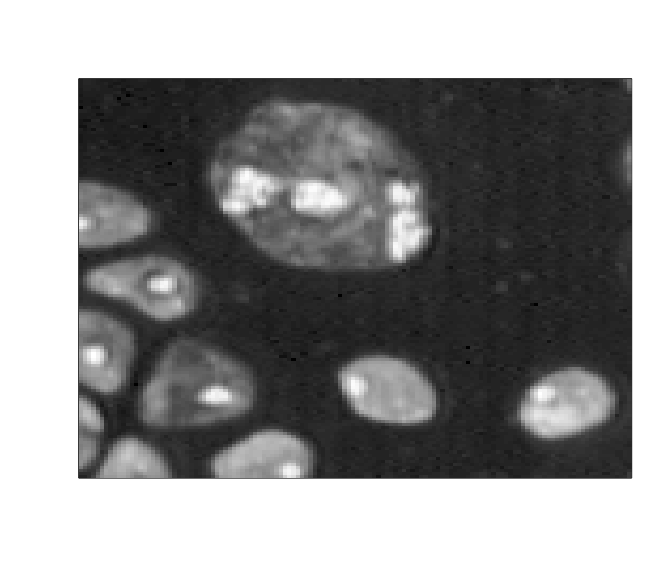

It’s a picture of cells, the black part is where the cells are not. The threshold is supposed to tell us what is *dark* (not cell) and what is *bright* (cell). By playing around, we may discover that something like 20 might (for some purposes) be a good value.

```r
ijtiff::display(img[, , 1, 1] > 20)
```

[output not shown]

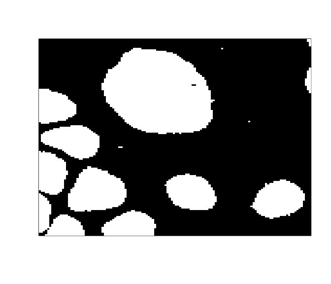

But what if we have many images and we don’t want to *play around*, we want a method of calculating the threshold automatically. http://imagej.net/Auto_Threshold gives many such methods and they are provided to you in R via this package. Go to that webpage for a nice comparison of the methods.

The function `auto_thresh()` finds the threshold, `mask()` gets the mask (an array with a `TRUE` for elements exceeding the threshold and `FALSE` elsewhere) and `apply_mask()` applies the mask to the original image by setting the elements that don’t exceed the threshold to `NA`.

Let’s see each with “Triangle” thresholding.

```r
auto_thresh(img, "tri")
```

```
#> [1] 14
#> attr(,"ignore_black")
#> [1] FALSE
#> attr(,"ignore_white")
#> [1] FALSE
#> attr(,"ignore_na")
#> [1] FALSE
#> attr(,"autothresh_method")
#> [1] "Triangle"
#> attr(,"class")
#> [1] "th"      "integer"
```

```r
ijtiff::display(mask(img, "tri"))
```

[output not shown]

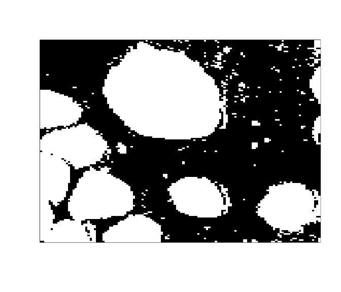

```r
ijtiff::display(apply_mask(img, "tri"))
```

[output not shown]

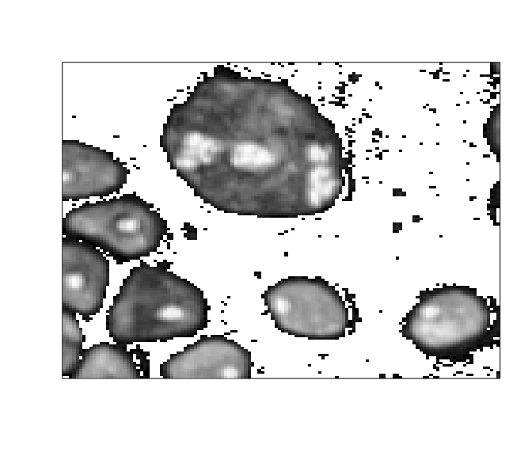